# Search Twitter Users

Collin Dever & Kaleb Crisci

2/9/2020

## Import Packages

To first search twitter users we will load the `rtweet` library. A library is a collection of functions that someone else has provided so that we don’t have to do the work of explaining to the computer what we want to do. We can just call the already created functions. We use functions from other packages here as well such as the `tidyverse`

```r
library(rtweet)
library(kableExtra)
library(tidyverse)
```

## Search Users

The rtweet package includes a function called `search_users()` once we have loaded the library we can simply type `search_users()`.

### Search Users Arguments

Arguments are information we pass to a function so that it knows what kind of information we are interested in returning. For example with `search_users()` we might want to give it a term to search users for. Here are the arguments we can pass to `search_users()`

```
search_users(q, n = 100, parse = TRUE, token = NULL, verbose = TRUE)
```

- **q [string]** - What search term you want to look for when looking for users. This seems to be related to `screen_name`, `user_name` and `description`
- **n [integer]** - the number of users you want to return. If you don’t specify the default will be to return 100 the most you can return is 1000
- **parse [boolean]** - Whether to return the twitter response object (JSON) or a data.frame the default is TRUE and that’s the best thing to leave it as. It will make working with the data easier.
- **token [Token]** - If you have a developer token created by the `create_token()` function you can pass it with this argument. It should not be needed for a`search_users()` call
- **verbose [boolean]** - whether to output debug messages or not. This will print in the console what the function is working on and any errors it encounters.

### Search User Returns

The search_users function returns a list of user objects. User object contain a lot of data on users (90 variables!!) some are not very useful for our research while others can be quite useful. We will look at some useful ones below.

- **screen_name [string]** - This is the `@` name for the account it is permanent
- **name [string]** - This is the user’s display name and can be changed
- **description [string]** - The short text blurb on the user’s account
- **location [string]** - The user-defined location. This could be real place or not.
- **created_at [datetime]** - When the account was created
- **followers_count [numeric]** - number of followers account has
- **friends_count [numeric]** - number of accounts the user is following
- **listed_count [numeric]** - number of public list user is a member of
- **favourites_count [numeric]** - number of tweet user has liked in their lifetime
- **statuses_count [numeric]** - The number of tweets issued by the user

Here is an example output for what search_users returns. This is a very Long table (90 variables!!) but you can scroll sideways to see it all.

```r
data <- search_users(q = "chico", n = 10, verbose = FALSE)
kable(data, "html") %>%
  kable_styling("striped") %>%
  scroll_box(width = "100%")
```

| user_id | status_id | created_at | screen_name | text | source | display_text_width | reply_to_status_id | reply_to_user_id | reply_to_screen_name | is_quote | is_retweet | favorite_count | retweet_count | quote_count | reply_count | hashtags | symbols | urls_url | urls_t.co | urls_expanded_url | media_url | media_t.co | media_expanded_url | media_type | ext_media_url | ext_media_t.co | ext_media_expanded_url | ext_media_type | mentions_user_id | … |
| --- | --- | --- | --- | --- | --- | --- | --- | --- | --- | --- | --- | --- | --- | --- | --- | --- | --- | --- | --- | --- | --- | --- | --- | --- | --- | --- | --- | --- | --- | --- |
| 17068492 | 1243686001702289408 | 1585352824 | ChicoState | Made it through the first week of virtual classes! Take some well-deserved rest this weekend—maybe spend some (socially distanced) time in nature to relax. (📸 by @jasonhalley_csu) https://t.co/0exNvZS… | Sprout Social | 180 | NA | NA | NA | FALSE | FALSE | 170 | 28 | NA | NA | NA | NA | NA | NA | NA | http://pbs.twimg.com/media/EUJ1zqWXkAIsLDv.jpg | https://t.co/0exNvZSEXJ | https://twitter.com/ChicoState/status/1243686001702289408/photo/1 | photo | c(“http://pbs.twimg.com/media/EUJ1zqWXkAIsLDv.jpg”, “http://pbs.twimg.com/media/EUJ10DgWkAA1Y8W.jpg”, “http://pbs.twimg.com/media/EUJ10aeWsAAH70M.jpg”, “http://pbs.twimg.com/media/EUJ10rzXkAE7kfx.jpg”… | c(“https://t.co/0exNvZSEXJ”, “https://t.co/0exNvZSEXJ”, “https://t.co/0exNvZSEXJ”, “https://t.co/0exNvZSEXJ”) | c(“https://twitter.com/ChicoState/status/1243686001702289408/photo/1”, “https://twitter.com/ChicoState/status/1243686001702289408/photo/1”, “https://twitter.com/ChicoState/status/1243686001702289408/p… | NA | 403935444 | … |
| 41171271 | 1244044718578774016 | 1585438348 | ChicoER | Phil Bryant All-Star Game rosters finalized prior to postponement of annual Northern Section basketball showcase https://t.co/50ehM1cJ68 | SocialFlow | 136 | NA | NA | NA | FALSE | FALSE | 0 | 0 | NA | NA | NA | NA | trib.al/5DJu8LT | https://t.co/50ehM1cJ68 | https://trib.al/5DJu8LT | NA | NA | NA | NA | NA | NA | NA | NA | NA | … |
| 70509424 | 1243862550518915074 | 1585394916 | Chicos | An #OOTD for all your virtual plans. From museum visits to Broadway plays, we’ve created a list of 24 activities to get you through the weekend. Click here to read more on our blog, Inside Chic: https… | Sprinklr | 218 | NA | NA | NA | FALSE | FALSE | 7 | 1 | NA | NA | OOTD | NA | spr.ly/60101vUPo | https://t.co/FrUHPyA88i | http://spr.ly/60101vUPo | http://pbs.twimg.com/media/EUMWZbjWAAEDih4.jpg | https://t.co/V8e54eK8Te | https://twitter.com/Chicos/status/1243862550518915074/photo/1 | photo | http://pbs.twimg.com/media/EUMWZbjWAAEDih4.jpg | https://t.co/V8e54eK8Te | https://twitter.com/Chicos/status/1243862550518915074/photo/1 | NA | NA | … |
| 412795908 | 1243313256644644866 | 1585263954 | chicoflores | And the results are in… As voted by the #JackArmy, our greatest away win 👇 🏆 Valencia 0-3 Swansea 🏆 Thanks for voting! https://t.co/6RHf8bVini | Twitter for iPhone | 140 | NA | NA | NA | FALSE | TRUE | 0 | 14 | NA | NA | JackArmy | NA | NA | NA | NA | NA | NA | NA | NA | NA | NA | NA | NA | 472385266 | … |
| 48035012 | 1243998871501537280 | 1585427418 | chicoharlan | This is a singular story of suffering, one among thousands and thousands, which makes this pandemic all that much more unimaginable. https://t.co/kRPzJGQcUf | Twitter for iPhone | 140 | NA | NA | NA | FALSE | TRUE | 0 | 51 | NA | NA | NA | NA | NA | NA | NA | NA | NA | NA | NA | NA | NA | NA | NA | 121857220 | … |
| 1227722562 | 1243936892606971904 | 1585412641 | TopoChicoUSA | At Poison Girl, noon-8pm daily. Curbside service for hot dogs, beer and booze. @topochicousa @jimbeamofficial Come and get it. #poisongirllovesyou #littledipperlovesyou #supportbartenders https://t.co… | Twitter for iPhone | 139 | NA | NA | NA | FALSE | TRUE | 0 | 1 | NA | NA | NA | NA | NA | NA | NA | NA | NA | NA | NA | NA | NA | NA | NA | c(“161703581”, “1227722562”, “2518552490”) | … |
| 118247024 | 1243596639073427458 | 1585331518 | chicoBean | How long y’all think we gon be…. https://t.co/Du4GpCeW6r | Twitter for iPhone | 34 | NA | NA | NA | FALSE | FALSE | 40562 | 10931 | NA | NA | NA | NA | NA | NA | NA | http://pbs.twimg.com/media/EUIkjHEXYAAWY9Q.jpg | https://t.co/Du4GpCeW6r | https://twitter.com/chicoBean/status/1243596639073427458/photo/1 | photo | http://pbs.twimg.com/media/EUIkjHEXYAAWY9Q.jpg | https://t.co/Du4GpCeW6r | https://twitter.com/chicoBean/status/1243596639073427458/photo/1 | NA | NA | … |
| 3314757086 | 1241149321023639552 | 1584748032 | ChicoFD | Today our recruit firefighters trained on search and rescue techniques at the Fire Training Center. In this picture, you see the thermal imaging outline of a recruit firefighter as he works through ze… | Twitter for iPhone | 245 | NA | NA | NA | FALSE | FALSE | 11 | 1 | NA | NA | c(“ChicoFD”, “ChicoFire”) | NA | NA | NA | NA | http://pbs.twimg.com/media/ETlytxJU0AEqcee.jpg | https://t.co/vaoNvzljzM | https://twitter.com/ChicoFD/status/1241149321023639552/photo/1 | photo | http://pbs.twimg.com/media/ETlytxJU0AEqcee.jpg | https://t.co/vaoNvzljzM | https://twitter.com/ChicoFD/status/1241149321023639552/photo/1 | NA | NA | … |
| 539247527 | 1243351640259719169 | 1585273106 | ChicoChamber | CARD is opening a program to provide childcare options for children of critical workers who do not have access to typical care because of COVID-19 closures. Details in the link. https://t.co/QEGpWyvuI… | Twitter Web App | 140 | NA | NA | NA | FALSE | TRUE | 0 | 5 | NA | NA | NA | NA | NA | NA | NA | NA | NA | NA | NA | NA | NA | NA | NA | 43942200 | … |
| 119115558 | 1242225460647321601 | 1585004603 | ChicoPolice | Follow the link to the City of Chico COVID 19 Press Briefing and information regarding public safety response. https://t.co/M0cjYtlAPM. @ChicoCityof @ChicoFD #chicoca #COVID19 #SocialDistancing #publi… | Twitter for iPhone | 207 | NA | NA | NA | FALSE | FALSE | 1 | 1 | NA | NA | c(“chicoca”, “COVID19”, “SocialDistancing”, “publicsafety”) | NA | facebook.com/OfficialCityof… | https://t.co/M0cjYtlAPM | https://www.facebook.com/OfficialCityofChico/videos/875224276249889/?vh=e&d=n | http://pbs.twimg.com/media/ET1FeG9U8AA5Wu5.jpg | https://t.co/0Cm9Y6s389 | https://twitter.com/ChicoPolice/status/1242225460647321601/photo/1 | photo | http://pbs.twimg.com/media/ET1FeG9U8AA5Wu5.jpg | https://t.co/0Cm9Y6s389 | https://twitter.com/ChicoPolice/status/1242225460647321601/photo/1 | NA | c(“1235295913494450176”, “3314757086”) | … |

## Code Example

This is an example of using the search_users() to find 10 users with the query term “chico”. This is the same function call we made above to show the results in the table.

```
search_users("chico", n = 10, verbose = FALSE)
```

## Measuring User Activity

We will now run that same query again and save the results we save into a variable called `statuses` so that we can further manipulate the data.

```r
statuses <- search_users("chico", n=10, verbose = FALSE)
```

We can use this data in a variety of ways. One thing we can do is visualize the number of lifetime tweets for individual users.

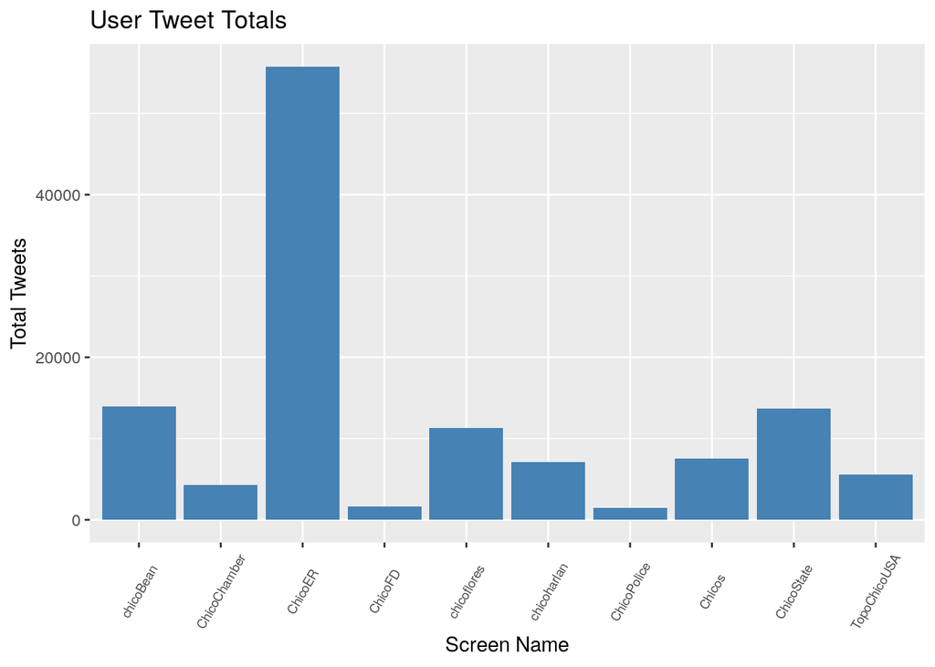

```r
ggplot(statuses, mapping = aes(y = statuses_count, x = screen_name )) + theme(axis.text.x=element_text(angle=60, size = 7, vjust = 0.5)) + geom_bar(stat="identity", fill="steelblue") + labs(y = "Total Tweets", x = "Screen Name") + ggtitle("User Tweet Totals")
```

We can use the lifetime tweets and the date that they created their account to determine how active each user is (tweets/time). First, we can create a new column to represent the number of weeks that a person has had their account.

```r
statuses <- statuses %>% select(statuses_count, account_created_at, screen_name)

statuses$timeHadAccount <- sapply(statuses$account_created_at, function(x){
  d <- as.POSIXct(Sys.time())
  d2 <- as.POSIXct(format(d, tz="UTC", usetz=TRUE), tz="UTC")
  return(difftime(d2, x, units ="weeks"))
})
```

Next, we can get the ratio of how active each user is (avg number of tweets per week)

```r
statuses$activity <- statuses$statuses_count/statuses$timeHadAccount
```

Now, we can plot this data to show each user’s level of activity.

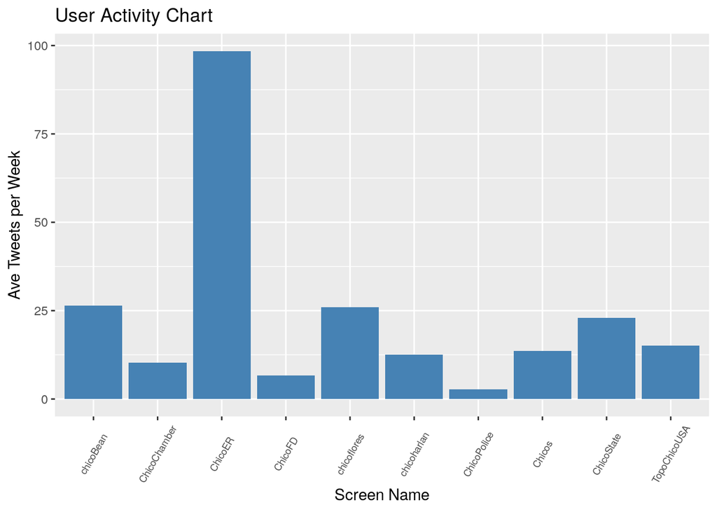

```r
ggplot(statuses, mapping = aes(y = activity, x = screen_name )) + theme(axis.text.x=element_text(angle=60, size = 7, vjust = 0.5)) + geom_bar(stat="identity", fill="steelblue") + labs(y = "Ave Tweets per Week", x = "Screen Name") + ggtitle("User Activity Chart")
```

## Who Mentioned the Corona Virus?

In this example, I will show how you can use simple pattern matching to find users for the search term `corona virus` and specifically mentioned the words “death, dead, infected” in their text description.

```r
users <- search_users("corona virus", n=100, verbose = FALSE)
```

The code below creates a new column in the data. A 1 will be placed in the column for that user if they mentioned any of the words we are searching for, and a 0 if they did not.

```r
sick <- c("death|dead|infected")
users$corona_virus <- sapply(users$text, function(x){
  if(any(grepl(sick, x))){
     return(1)
  }
  return(0)
})
```

Now, we can see how many of the 100 users wrote those words.

```r
sum(users$corona_virus)
```

```
## [1] 4
```

```r
users$text[users$corona_virus == 1]
```

```
## [1] "#Breaking: US coronavirus death toll hits 2,000"
## [2] "US #CoronaVirus: To date, a total of 120,076 cases and 1,993 total deaths and #COVID19 deaths have been confirmed in the United States.\n\n#CoronaVirusOutbreak https://t.co/9Wt8WohlNY"
## [3] "ITALY has TODAY confirmed 889 new death cases from coronavirus. Total deaths in Italy now is 10023."
## [4] "#NewsAlert |  Iran reports 139 new #coronavirus deaths, raising total to 2,517,\n\n#CoronavirusOutbreak #CoronaUpdate"
```

Or, if we want to see only the username of the users who said these words in their messages we can use this code:

```r
users$screen_name[users$corona_virus == 1]
```

```
## [1] "CoronaNumbers"  "CoronaVirusNow" "Obuchunju"      "21daylockdown"
```